# 스마트베타 분석

먼저 패키지와 함수를 불러옵니다.

```r
# open packages
library(readxl)
library(timetk)
library(xts)
library(PerformanceAnalytics)
```

```r
library(ggplot2)
library(tibble)
library(tidyr)
library(dplyr)
library(purrr)
library(lubridate)
library(knitr)
library(magrittr)
library(broom)
library(tibbletime)
# open function
source('fun.R')

options(scipen = 5)
options(digits = 4)
```

데이터를 클랜징 해줍니다.

```r
raw = readxl::read_xlsx('raw.xlsx')
```

```
## * `` -> ...1
## * `` -> ...3
## * `` -> ...4
## * `` -> ...5
## * `` -> ...6
## * … and 12 more problems
```

```r
ticker = raw %>% slice(9)
data = raw %>% slice(-1:-13) %>%
  set_names(ticker) %>%
  mutate_all(as.numeric) %>%
  rename('Date' = 'Symbol Name') %>%
  rename('QV' = 'FnGuide 퀄리티밸류 지수') %>%
  mutate(Date = as.Date(Date, origin = '1899-12-30'))
```

퀄리티밸류의 그래프를 확인해보죠. (2015-09-22일 상장)

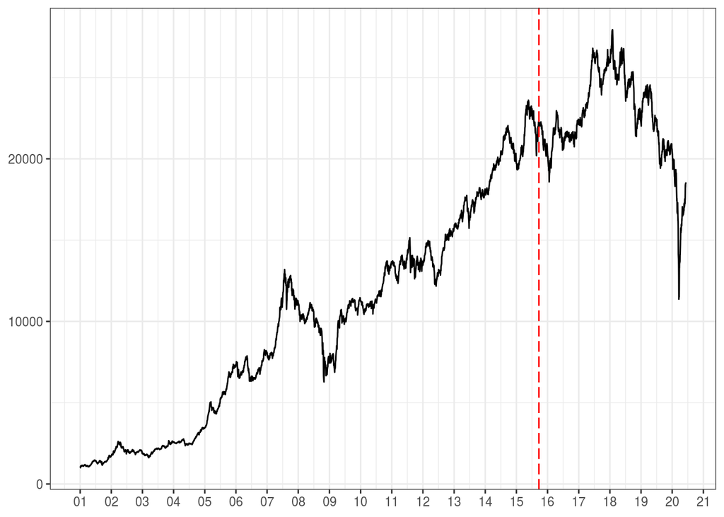

```r
data %>%
  ggplot(aes(x = Date, y = QV)) +
  geom_line() +
  geom_vline(xintercept = as.numeric(as.Date('2015-09-22')),
             color = 'red', linetype = "longdash") +
  scale_x_date(date_labels="%y",date_breaks  ="1 year")
```

18년 이후 지속적으로 하락하는 모습을 보임. 17년 이후 코스피 지수와 비교해보도록 함.

```r
qv_kospi =
  data %>% select(Date, 코스피, QV) %>%
  filter(Date >= '2017-01-01') %>%
  rename('KOSPI' = '코스피') %>%
  mutate_if(is.numeric, list(~./lag(.) - 1)) %>%
  mutate(gap = QV - KOSPI) %>%
  na.omit() %>%
  mutate(gap = cumprod(1+gap) - 1) %>%
  tk_xts(var = 'Date')
```

```
## Using column `Date` for date_var.
```

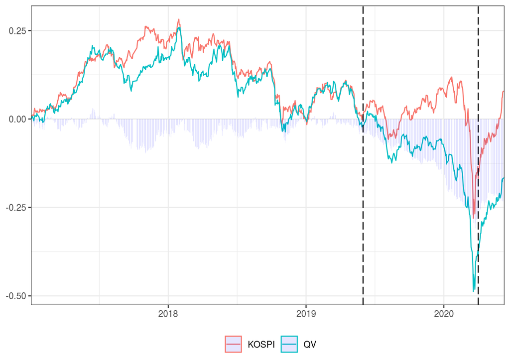

```r
qv_kospi[, c('KOSPI', 'QV')] %>%
  plot_cumulative() + geom_vline(xintercept = as.numeric(as.Date('2019-06-01')),
             color = 'black', linetype = "longdash") +
  geom_vline(xintercept = as.numeric(as.Date('2020-04-01')),
             color = 'black', linetype = "longdash") +
  geom_col(data = fortify.zoo(qv_kospi[, c('gap')]), aes(x = Index, y = gap),
           fill = 'blue', alpha = 0.1, width = 1)
```

사실 2019년 중반까지는 크게 차이가 없고, 19년 6월부터 차이가 벌어지는 중. 20년 4월부터는 다시 차이 줄이는 중.

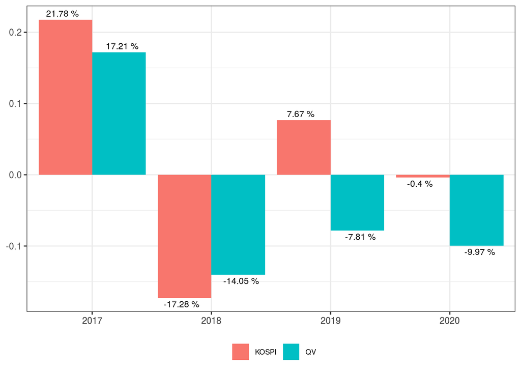

```r
qv_kospi[, c('KOSPI', 'QV')] %>% plot_yearly()
```

[코스피 / 코스피 대형주 / 코스피 중형주 / 코스피 소형주] 각각의 흐름을 살펴보도록 하자

```r
kospi_ret = data %>% select(Date, contains('코스피')) %>%
  rename('KOSPI' = '코스피', 'BIG' = '코스피대형주',
         'MED' = '코스피중형주', 'SMALL' = '코스피소형주') %>%
  filter(Date >= '2017-01-01') %>%
  tk_xts(var = 'Date') %>%
  Return.calculate()
```

```
## Using column `Date` for date_var.
```

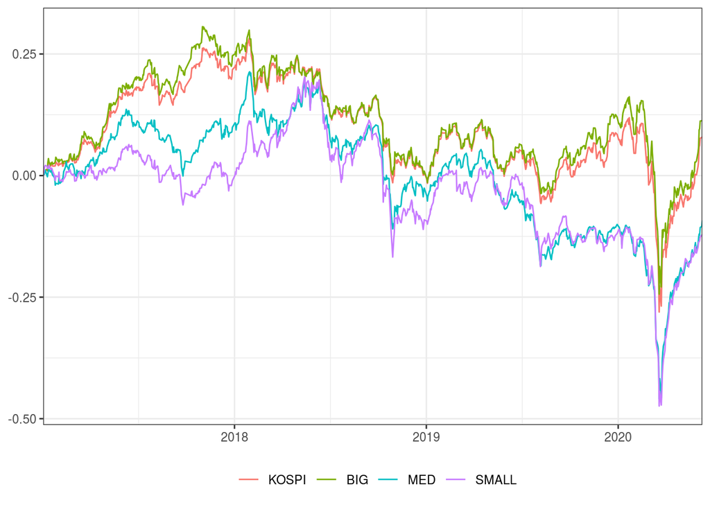

```r
kospi_ret %>%
  plot_cumulative()
```

대형주 대비 중형주 / 소형주가 훨씬 많이 떨어진 모습을 보임

```r
kospi_ret %>%  na.omit() %>% cor() %>%
  round(., 2) %>%
  kable() %>%  kableExtra::kable_styling()
```

|  | KOSPI | BIG | MED | SMALL |
| --- | --- | --- | --- | --- |
| KOSPI | 1.00 | 0.99 | 0.84 | 0.76 |
| BIG | 0.99 | 1.00 | 0.77 | 0.69 |
| MED | 0.84 | 0.77 | 1.00 | 0.90 |
| SMALL | 0.76 | 0.69 | 0.90 | 1.00 |

전반적으로 코스피와 중/소형주의 상관관계도 대형주보다 낮은편

다음으로 MKT, SMB, HML, UMD 팩터를 생성

```r
data_ret = data %>%
  mutate_if(is.numeric, list(~./lag(.) - 1)) %>% na.omit()

f_MKT = data_ret %>% select(Date, 코스피) %>% tk_xts(var = 'Date')
```

```
## Using column `Date` for date_var.
```

```r
f_SMB = data_ret %>%
  mutate(SMB =
              ((`Size & Book Value(2X3) 소형 - High` +
                      `Size & Book Value(2X3) 소형 - Medium` +
                      `Size & Book Value(2X3) 소형 - Low`) -
              (`Size & Book Value(2X3) 대형 - High` +
                     `Size & Book Value(2X3) 대형 - Medium` +
                     `Size & Book Value(2X3) 대형 - Low`)) %>% divide_by(3)
  ) %>% select(Date, SMB) %>% tk_xts(var = 'Date')
```

```
## Using column `Date` for date_var.
```

```r
f_HML = data_ret %>%
  mutate(HML =
              ((`Size & Book Value(2X3) 소형 - High` +
                      `Size & Book Value(2X3) 대형 - High`) -
                 (`Size & Book Value(2X3) 소형 - Low` +
                     `Size & Book Value(2X3) 대형 - Low`)) %>% divide_by(2)
  ) %>% select(Date, HML) %>% tk_xts(var = 'Date')
```

```
## Using column `Date` for date_var.
```

```r
f_UMD = data_ret %>%
  mutate(UMD =
              ((`Size & Momentum(2X3) 소형 - Up` +
                      `Size & Momentum(2X3) 대형 - Up`) -
                 (`Size & Momentum(2X3) 소형 - Down` +
                     `Size & Momentum(2X3) 대형 - Down`)) %>% divide_by(2)
  ) %>% select(Date, UMD) %>% tk_xts(var = 'Date')
```

```
## Using column `Date` for date_var.
```

```r
f = cbind(f_MKT, f_SMB, f_HML, f_UMD)
colnames(f)[1] = 'MKT'
```

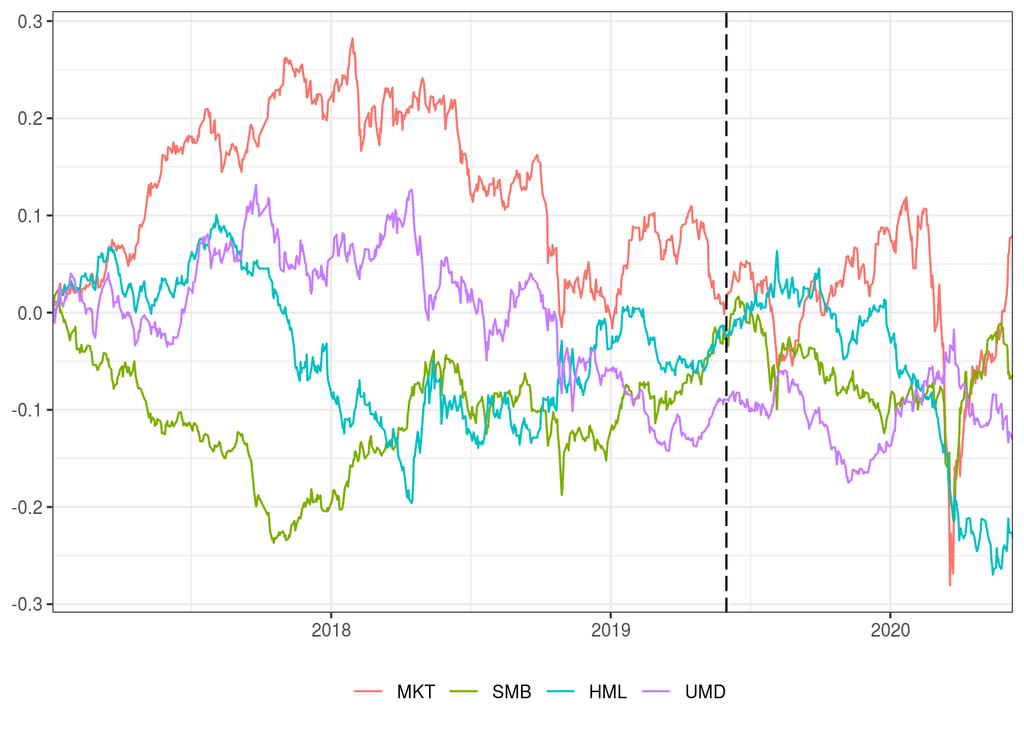

```r
p = f["2017::"] %>% plot_cumulative()
p + geom_vline(xintercept = as.numeric(as.Date('2015-09-22')),
             color = 'red', linetype = "longdash") +
  geom_vline(xintercept = as.numeric(as.Date('2019-06-01')),
             color = 'black', linetype = "longdash")
```

```
## Using column `Date` for date_var.
```

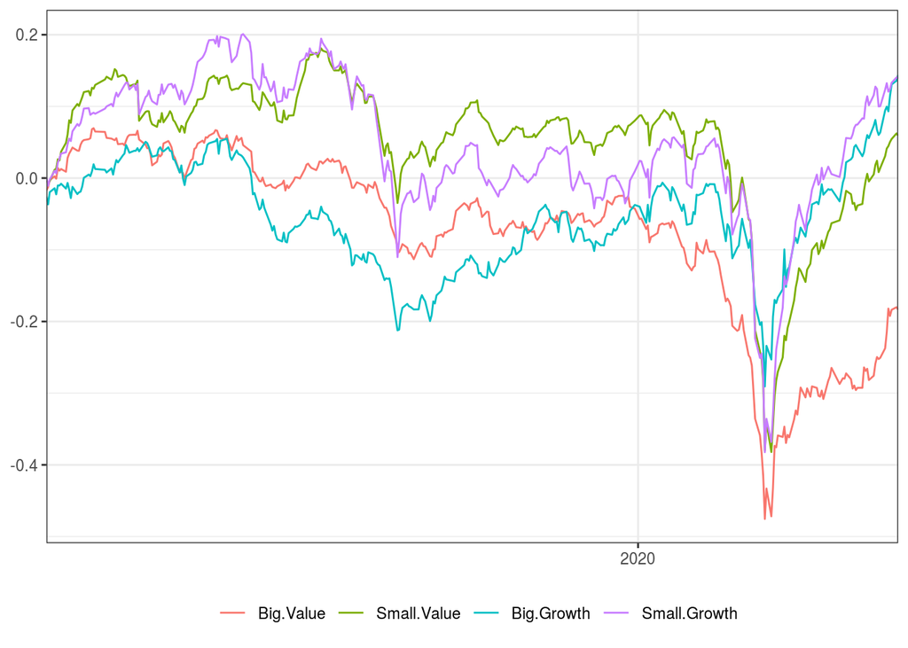

```r
data_ret %>%
  filter(Date >= '2019-01-01') %>%
  select(Date, contains('High'), contains('Low')) %>%
  set_colnames(c('Date', 'Big Value', 'Small Value', 'Big Growth', 'Small Growth')) %>%
  tk_xts(var = 'Date') %>% plot_cumulative()
```

19년 이후 Growth가 Value 대비 더 좋은 성과. 특히 대형가치주는 매우 부진한 성과를 보임

```r
data_bind = data_ret %>% select(Date, QV) %>% tk_xts(var = 'Date') %>%
  cbind(f)
```

```
## Using column `Date` for date_var.
```

```r
reg_1 = lm(QV ~ MKT, data = data_bind)
reg_2 = lm(QV ~ ., data = data_bind)

tidy(reg_1) %>% kable() %>% kableExtra::kable_styling()
```

| term | estimate | std.error | statistic | p.value |
| --- | --- | --- | --- | --- |
| (Intercept) | 0.0004 | 0.0001 | 4.136 | 0 |
| MKT | 0.7060 | 0.0070 | 101.327 | 0 |

```r
tidy(reg_2) %>% kable() %>% kableExtra::kable_styling()
```

| term | estimate | std.error | statistic | p.value |
| --- | --- | --- | --- | --- |
| (Intercept) | 0.0002 | 0.0001 | 1.980 | 0.0477 |
| MKT | 0.8541 | 0.0064 | 133.879 | 0.0000 |
| SMB | 0.3934 | 0.0091 | 43.162 | 0.0000 |
| HML | 0.4111 | 0.0115 | 35.886 | 0.0000 |
| UMD | -0.0614 | 0.0089 | -6.874 | 0.0000 |

```r
w = 1300
coeff = list()
tval = list()

for (i in (w+1) : nrow(data_bind)) {

  temp = data_bind[i : (i -w), ]
  reg = lm(QV ~ MKT + SMB + HML + UMD, data = temp)

  coeff[[i]] = xts(t(reg$coefficients), order.by = index(data_bind)[i])
  tval[[i]] = xts(t(summary(reg)[["coefficients"]][, "t value"]),
                  order.by = index(data_bind)[i])

}

coeff = do.call(rbind, coeff)
tval = do.call(rbind, tval)
```

5년 롤링 회귀계수

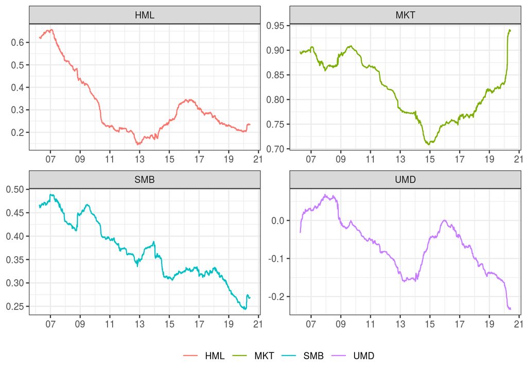

```r
coeff %>%
  fortify.zoo() %>% select(-'(Intercept)') %>%
  gather(key, value, -Index) %>%
  ggplot(aes(x = Index, y = value, group = key)) +
  geom_line(aes(color = key)) +
  scale_x_date(date_labels="%y",date_breaks  ="2 year") +
  facet_wrap(~ key, scales = 'free')
```

시장 노출도만 계속 커짐

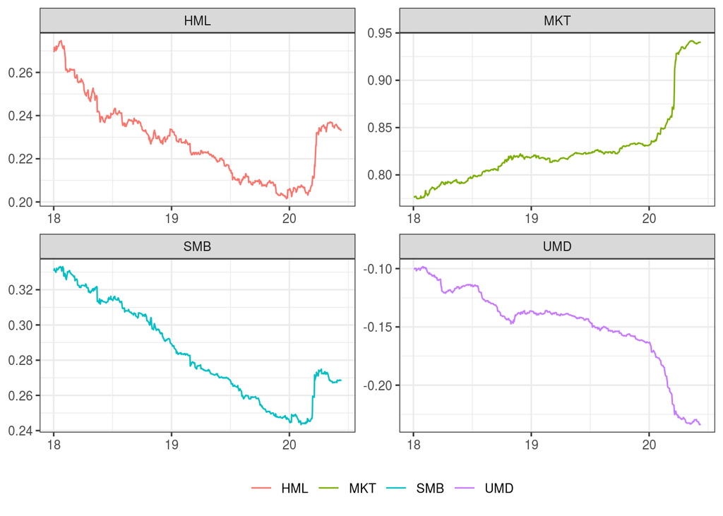

```r
coeff %>%
  fortify.zoo() %>% select(-'(Intercept)') %>%
  filter(Index >= '2018-01-01') %>%
  gather(key, value, -Index) %>%
  ggplot(aes(x = Index, y = value, group = key)) +
  geom_line(aes(color = key)) +
  scale_x_date(date_labels="%y",date_breaks  ="1 year") +
  facet_wrap(~ key, scales = 'free')
```

최근엔 가치 + 소형주도 같이 증가하지만, 시장노출도가 여전히 큰 상황.

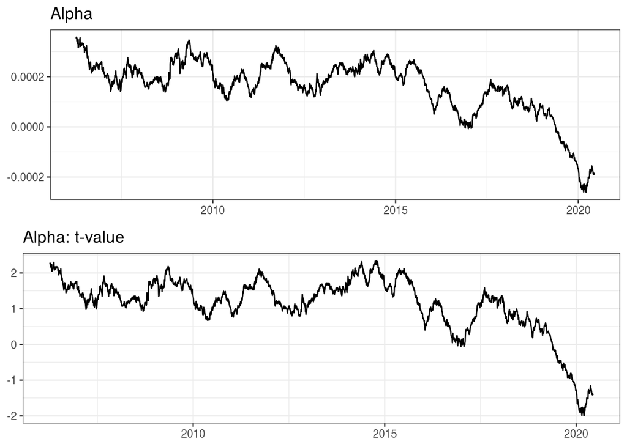

```r
p1 = coeff %>%
  fortify.zoo() %>% select(Index, '(Intercept)') %>%
  ggplot(aes(x = Index, y = `(Intercept)`)) +
  geom_line() +
  ggtitle('Alpha')

p2 = tval %>%
  fortify.zoo() %>%
  select(Index, '(Intercept)') %>%
  ggplot(aes(x = Index, y = `(Intercept)`)) +
  geom_line() +
  ggtitle('Alpha: t-value')

gridExtra::grid.arrange(p1, p2)
```

4팩터 기준 알파가 지속적으로 감소하고 있음